# Analyse statistique en utilisant DESeq2

Chaimae EL HOUJJAJI - Kexin LI - Anthony MOREAU - Pauline TURK

29/11/2021

### REMARQUES PREALABLES

Ce fichier html a été généré en important les résultat des counts sur notre machine locale. L'idéal aurait été de pouvoir générer ce html grâce à une règle sur Snakefile. Par manque de temps nous n'avons pas pu le réaliser mais nous tenions tout de même à insérer le fichier html généré avec les commentaires associés. La règle Snakefile actuelle renvoie en sortie un fichier Rdata ainsi qu'un fichier Rplots.pdf avec les mêmes graphes que ci-dessous.

### A faire avant de lancer les plots

Pour installer DESeq2, IL FAUT LA VERSION 4.1 de R d'après internet

Si DESeq2 ne veut toujours pas s'installer, copier coller cela sur votre Console :

if (!requireNamespace("BiocManager", quietly = TRUE))

install.packages("BiocManager")

BiocManager::install("DESeq2")

### Chargement de la librairie DESeq2

```r
library("DESeq2")
```

### Télechargement des données

On télécharge les données depuis les fichiers de count dans le dossier result qui a été généré par le Snakefile et que l'on a importé sur notre machine local à l'emplacement indiqué dans le chunk suivant.

```r
SRR628582 <- read.table("~/Desktop/hackaton-ACKP-main/result/SRR628582.counts", head=TRUE)
SRR628583 <- read.table("~/Desktop/hackaton-ACKP-main/result/SRR628583.counts", head=TRUE)
SRR628584 <- read.table("~/Desktop/hackaton-ACKP-main/result/SRR628584.counts", head=TRUE)
SRR628585 <- read.table("~/Desktop/hackaton-ACKP-main/result/SRR628585.counts", head=TRUE)
SRR628586 <- read.table("~/Desktop/hackaton-ACKP-main/result/SRR628586.counts", head=TRUE)
SRR628587 <- read.table("~/Desktop/hackaton-ACKP-main/result/SRR628587.counts", head=TRUE)
SRR628588 <- read.table("~/Desktop/hackaton-ACKP-main/result/SRR628588.counts", head=TRUE)
SRR628589 <- read.table("~/Desktop/hackaton-ACKP-main/result/SRR628589.counts", head=TRUE)
```

### Création des jeu de données

On créée dans la variable `data` le jeu de donnée, avec le nom du GeneId en 1ère colonne et les counts des 8 SRR par la suite.

```r
data <- data.frame(SRR628582$Geneid,SRR628582$mapping.SRR628582.bam,SRR628583$mapping.SRR628583.bam,SRR628584$mapping.SRR628584.bam,SRR628585$mapping.SRR628585.bam,SRR628586$mapping.SRR628586.bam,SRR628587$mapping.SRR628587.bam,SRR628588$mapping.SRR628588.bam,SRR628589$mapping.SRR628589.bam)
```

On crée les métadonnées: récuperation au format data.frame des labels :

```r
samples = c("SRR628582", "SRR628583", "SRR628584", "SRR628585", "SRR628586", "SRR628587", "SRR628588", "SRR628589")
Type_M_WT = c("M", "M", "WT", "WT", "WT", "WT", "WT", "M") # M: mutants, WT: Wild-Type
MetaData = data.frame(samples, Type_M_WT)
```

On visualise les premières lignes de la variable `data`

```r
head(data)
```

```
##   SRR628582.Geneid SRR628582.mapping.SRR628582.bam
## 1  ENSG00000223972                               0
## 2  ENSG00000227232                             228
## 3  ENSG00000278267                               0
## 4  ENSG00000243485                               0
## 5  ENSG00000284332                               0
## 6  ENSG00000237613                               0
##   SRR628583.mapping.SRR628583.bam SRR628584.mapping.SRR628584.bam
## 1                               0                               0
## 2                             858                             309
## 3                               0                               0
## 4                               1                               0
## 5                               0                               0
## 6                               0                               0
##   SRR628585.mapping.SRR628585.bam SRR628586.mapping.SRR628586.bam
```

[output cut: 20 more lines]

On visualise les données dans la variable `MetaData`

```r
print(MetaData)
```

```
##     samples Type_M_WT
## 1 SRR628582         M
## 2 SRR628583         M
## 3 SRR628584        WT
## 4 SRR628585        WT
## 5 SRR628586        WT
## 6 SRR628587        WT
## 7 SRR628588        WT
## 8 SRR628589         M
```

### Construction de l'objet DESEQDataSet

```r
dds <- DESeqDataSetFromMatrix(countData=data, colData=MetaData, design=~Type_M_WT, tidy = TRUE)
```

Regardons à quoi ressemble le `dds` :

```r
print(dds)
```

```
## class: DESeqDataSet
## dim: 60612 8
## metadata(1): version
## assays(1): counts
## rownames(60612): ENSG00000223972 ENSG00000227232 ... ENSG00000210195
##   ENSG00000210196
## rowData names(0):
## colnames(8): SRR628582.mapping.SRR628582.bam
##   SRR628583.mapping.SRR628583.bam ... SRR628588.mapping.SRR628588.bam
##   SRR628589.mapping.SRR628589.bam
## colData names(2): samples Type_M_WT
```

### Lançons la fonction DESeq et Regardons la table des résultats

```r
dds <- DESeq(dds)
res <- results(dds)
dds$Type_M_WT <- relevel(dds$Type_M_WT, ref ="WT") # on modifie pour que la reference soit le WT et pas le M (qui est pris automatiquement car alphabétiquement il est plus proche)
levels(dds$Type_M_WT) # on vérifie que le WT a bien été pris comme référence
```

```
## [1] "WT" "M"
```

```r
head(results(dds, tidy=TRUE))
```

```
##               row     baseMean log2FoldChange     lfcSE       stat    pvalue
## 1 ENSG00000223972   0.00000000             NA        NA         NA        NA
## 2 ENSG00000227232 391.16994645     -0.4383304 0.6137696 -0.7141610 0.4751276
## 3 ENSG00000278267   0.00000000             NA        NA         NA        NA
## 4 ENSG00000243485   0.08724215     -0.5593548 3.6496942 -0.1532607 0.8781927
## 5 ENSG00000284332   0.00000000             NA        NA         NA        NA
## 6 ENSG00000237613   0.00000000             NA        NA         NA        NA
##        padj
## 1        NA
## 2 0.8653772
## 3        NA
## 4        NA
## 5        NA
## 6        NA
```

### Résumé de l'expression différentiel des gènes

```r
summary(res)
```

```
##
## out of 28906 with nonzero total read count
## adjusted p-value < 0.1
## LFC > 0 (up)       : 166, 0.57%
## LFC < 0 (down)     : 1066, 3.7%
## outliers [1]       : 859, 3%
## low counts [2]     : 7921, 27%
## (mean count < 2)
## [1] see 'cooksCutoff' argument of ?results
## [2] see 'independentFiltering' argument of ?results
```

On souhaite maintenant comparer avec l'article 2. Pour cela on modifie les paramètres, on prend pvalue = 0,05 et LFC=1,5.

```r
res2 <- results(dds,alpha = 0.05, lfcThreshold = 1.5, pAdjustMethod = 'none')
summary(res2)
```

```
##
## out of 28906 with nonzero total read count
## adjusted p-value < 0.05
## LFC > 1.50 (up)    : 25, 0.086%
## LFC < -1.50 (down) : 625, 2.2%
## outliers [1]       : 859, 3%
## low counts [2]     : 0, 0%
## (mean count < 0)
## [1] see 'cooksCutoff' argument of ?results
## [2] see 'independentFiltering' argument of ?results
```

On affiche la liste des 10 gènes avec les padj les plus faibles donc les 10 gènes avec une Expression Différentielle la plus forte.

```r
res <- res[order(res$padj),]
head(res, 10) # pour afficher la liste des 10 gènes avec les padj les plus faibles
```

```
## log2 fold change (MLE): Type M WT WT vs M
## Wald test p-value: Type M WT WT vs M
## DataFrame with 10 rows and 6 columns
##                  baseMean log2FoldChange     lfcSE      stat      pvalue
##                 <numeric>      <numeric> <numeric> <numeric>   <numeric>
## ENSG00000164659  287.6876        4.96512  0.519133   9.56426 1.13003e-21
## ENSG00000234261   79.8452       -5.47104  0.767031  -7.13275 9.83854e-13
## ENSG00000153283   52.1260       -5.64968  0.851949  -6.63147 3.32350e-11
## ENSG00000214212   63.1251       -4.09607  0.613801  -6.67329 2.50127e-11
## ENSG00000142621   27.2160       -5.76809  0.877840  -6.57077 5.00545e-11
## ENSG00000186973   28.6401       -6.41407  0.985697  -6.50714 7.65964e-11
## ENSG00000286122   26.9361       -7.31399  1.126520  -6.49255 8.43927e-11
## ENSG00000103449   74.1049        4.30703  0.672830   6.40136 1.53994e-10
## ENSG00000007038   32.3919       -8.75270  1.390835  -6.29313 3.11131e-10
## ENSG00000108846   33.4551       -4.26274  0.678066  -6.28662 3.24458e-10
##                        padj
##                   <numeric>
## ENSG00000164659 2.27430e-17
## ENSG00000234261 9.90052e-09
## ENSG00000153283 1.67222e-07
## ENSG00000214212 1.67222e-07
## ENSG00000142621 2.01479e-07
## ENSG00000186973 2.42641e-07
## ENSG00000286122 2.42641e-07
## ENSG00000103449 3.87410e-07
## ENSG00000007038 6.53003e-07
## ENSG00000108846 6.53003e-07
```

Ainsi on a les identifiants des 10 gènes avec une pdjust la plus faibles, essayons de réaliser des graphiques pour mieux visualiser l'expression différentielle de ces gènes.

### On réalise des plotCounts pour comparer les comptes normalisés entre les mutants et les WildType pour quelques gènes

Exemple du gène ENSG00000115524 = SF3B1 dont parlent les articles

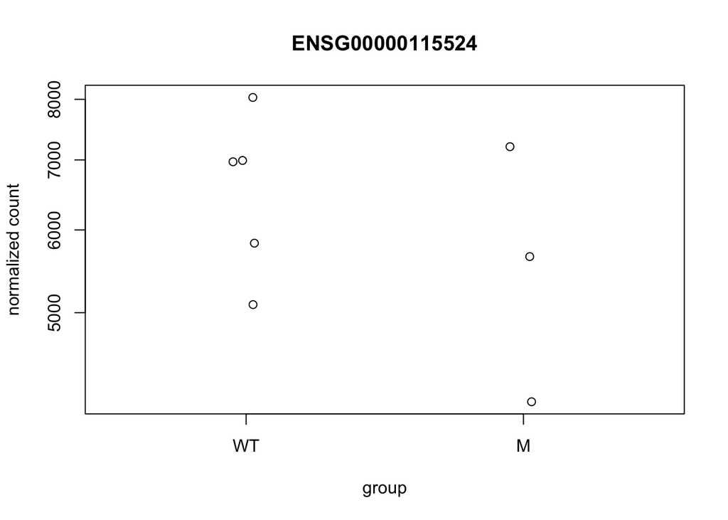

```r
par(mfrow=c(1,1))
plotCounts(dds, gene="ENSG00000115524", intgroup="Type_M_WT")
```

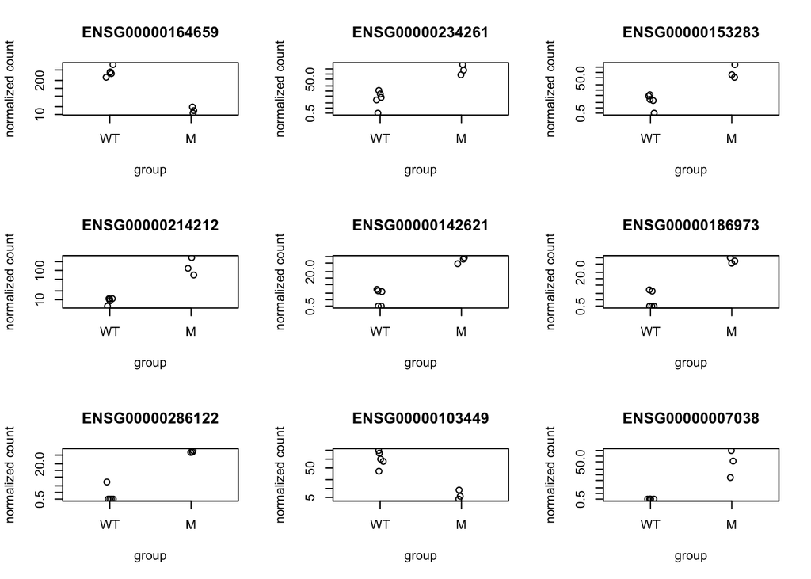

```r
par(mfrow=c(3,3))  # par(mfrow=c(2,3)) si je fais 6 graphes, ça les classes en 2 lignes 3 colonnes par exemple

plotCounts(dds, gene="ENSG00000164659", intgroup="Type_M_WT")
plotCounts(dds, gene="ENSG00000234261", intgroup="Type_M_WT")
plotCounts(dds, gene="ENSG00000153283", intgroup="Type_M_WT")
plotCounts(dds, gene="ENSG00000214212", intgroup="Type_M_WT")
plotCounts(dds, gene="ENSG00000142621", intgroup="Type_M_WT")
plotCounts(dds, gene="ENSG00000186973", intgroup="Type_M_WT")
plotCounts(dds, gene="ENSG00000286122", intgroup="Type_M_WT")
plotCounts(dds, gene="ENSG00000103449", intgroup="Type_M_WT")
plotCounts(dds, gene="ENSG00000007038", intgroup="Type_M_WT")
```

### Réalisation du Volcano Plot

On réalise ici un Volcano Plot avec la librairie DESeq2, toutefois, sur le deuxième fichier R, on a tracé une version améliorée, le EnhancedVolcano Plot qui permet d'avoir les étiquettes des gènes sur les points.

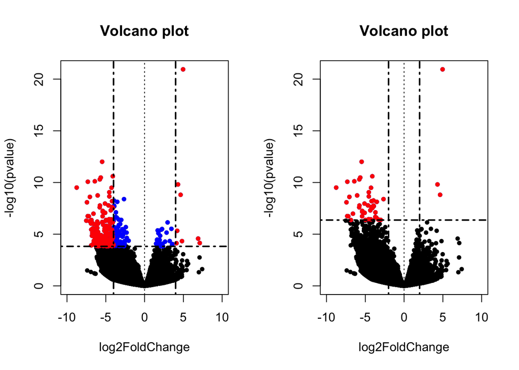

```r
#reset par
par(mfrow=c(1,2))

# Faire un volcano plot basique
with(res, plot(log2FoldChange, -log10(pvalue), pch=20, main="Volcano plot", xlim=c(-10,10)))

# Ajouter des points colorés: padj<.01 et LFC = 4
with(subset(res, padj<.01 ), points(log2FoldChange, -log10(pvalue), pch=20, col="blue"))
with(subset(res, padj<.01 & abs(log2FoldChange)>4), points(log2FoldChange, -log10(pvalue), pch=20, col="red"))
abline(v=0, col="black", lty=3, lwd=1.0)
abline(v=-4, col="black", lty=4, lwd=2.0)
abline(v=4, col="black", lty=4, lwd=2.0)
abline(h=-log10(max(res$pvalue[res$padj<.01], na.rm=TRUE)), col="black", lty=4, lwd=2.0)


# Faire un volcano plot basique
with(res, plot(log2FoldChange, -log10(pvalue), pch=20, main="Volcano plot", xlim=c(-10,10)))

# Ajouter des points colorés: padj<.002 et LFC = 2
with(subset(res, padj<.0002 ), points(log2FoldChange, -log10(pvalue), pch=20, col="blue"))
with(subset(res, padj<.0002 & abs(log2FoldChange)>2), points(log2FoldChange, -log10(pvalue), pch=20, col="red"))
abline(v=0, col="black", lty=3, lwd=1.0)
abline(v=-2, col="black", lty=4, lwd=2.0)
abline(v=2, col="black", lty=4, lwd=2.0)
abline(h=-log10(max(res$pvalue[res$padj<.0002], na.rm=TRUE)), col="black", lty=4, lwd=2.0)
```

### ACP avec la librairie DESeq2

Nous devons d'abord transformer les données bruts de comptage: la fonction vst effectuera une transformation stabilisant la variance.

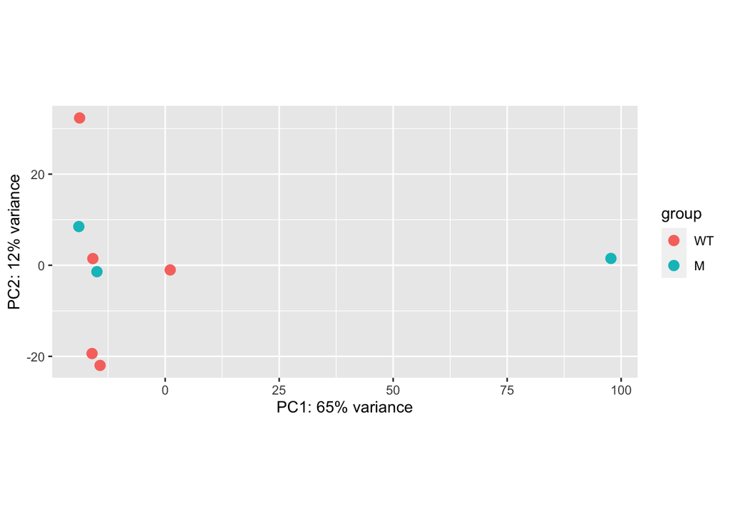

```r
vsdata <- vst(dds, blind=FALSE)
plotPCA(vsdata, intgroup="Type_M_WT")
```